# Part II - Presentation of ProsperLoanData Exploration

## by Andrew Muhoro

## Investigation Overview

For this investigation, my goal is to look at what factors affect the loan amount given and how other loan elements interact with each other directly or indirectly.

## Dataset Overview

This data set contains 113,937 loans with 81 variables on each loan, including loan amount, borrower rate (or interest rate), current loan status, borrower income, and many others. See the data dictionary attached to understand the dataset's variables.

|  | ListingNumber | CreditGrade | Term | LoanStatus | ClosedDate | BorrowerAPR | BorrowerRate | ProsperScore | BorrowerState | Occupation | ... | LP_ServiceFees | LP_CollectionFees | LP_GrossPrincipalLoss | LP_NetPrincipalLoss | LP_NonPrincipalRecoverypayments | PercentFunded | Recommendations | InvestmentFromFriendsCount | InvestmentFromFriendsAmount | Investors |
| --- | --- | --- | --- | --- | --- | --- | --- | --- | --- | --- | --- | --- | --- | --- | --- | --- | --- | --- | --- | --- | --- |
| 0 | 193129 | C | 36 | Completed | 2009-08-14 00:00:00 | 0.16516 | 0.1580 | NaN | CO | Other | ... | -133.18 | 0.0 | 0.0 | 0.0 | 0.0 | 1.0 | 0 | 0 | 0.0 | 258 |
| 1 | 1209647 | NaN | 36 | Current | NaN | 0.12016 | 0.0920 | 7.0 | CO | Professional | ... | 0.00 | 0.0 | 0.0 | 0.0 | 0.0 | 1.0 | 0 | 0 | 0.0 | 1 |
| 2 | 81716 | HR | 36 | Completed | 2009-12-17 00:00:00 | 0.28269 | 0.2750 | NaN | GA | Other | ... | -24.20 | 0.0 | 0.0 | 0.0 | 0.0 | 1.0 | 0 | 0 | 0.0 | 41 |
| 3 | 658116 | NaN | 36 | Current | NaN | 0.12528 | 0.0974 | 9.0 | GA | Skilled Labor | ... | -108.01 | 0.0 | 0.0 | 0.0 | 0.0 | 1.0 | 0 | 0 | 0.0 | 158 |
| 4 | 909464 | NaN | 36 | Current | NaN | 0.24614 | 0.2085 | 4.0 | MN | Executive | ... | -60.27 | 0.0 | 0.0 | 0.0 | 0.0 | 1.0 | 0 | 0 | 0.0 | 20 |

5 rows × 58 columns

## Viz 1: EmploymentStatus by Loan Original Amount

**During the data exploration I noted that being employed gave the borrower a chance to access larger loan amounts as seen in the box plot chart below. The Employed category had the largest amount of loans compared to the other categories.**

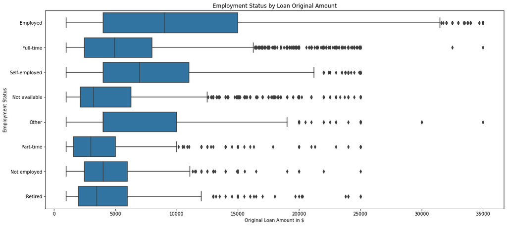

## Viz 2: Monthly Loan Payments by Loan Status and Prosper Score Distribution

**Looking at the plot below we can by the frequency of same dot-colour the accumalation of risk-category as seen in the ProperScore legend on the right side of the figure. The darker the colour, the lower the risk and the brighter the colour the higher the risk(>=10:low risk, <=2:high risk). With that we can see majority of low risk loans fall in the Current and Completed Loans. However, the Past Dues and Defaulted loans, etc have higher risks.**

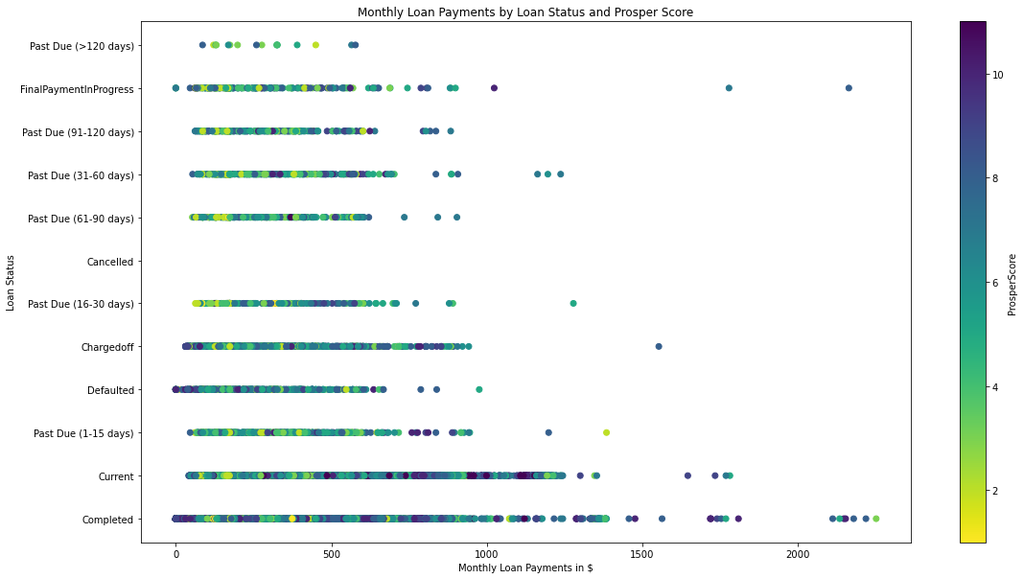

## Viz 3: Prosper Score by Borrower Rate and Borrower APR Distribution

**The BorrowerAPR and BorrowerRate have a strong positive relationship. An increase or decrease in either affects the other directly in the same trajectory. Majority of loans with lower BorrowerAPR & BorrowerRate have higher ProsperScore(lower risks) and visa-versa**

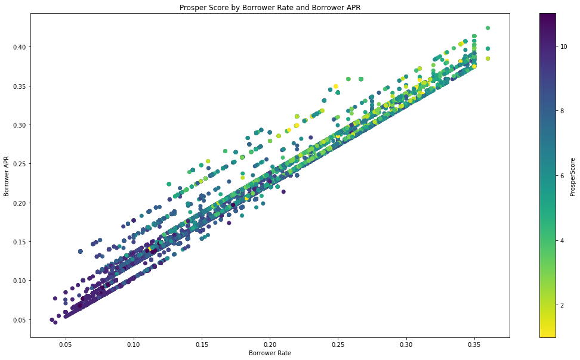